# Bike Sharing Data Visualizations

## by Benjamin KENETHA

## Investigation Overview

Pour ce projet d'analyse de données, nous commençons par présenter les distributions de nos variables d'intérêt qui sont le temps que dure l'emprunt d'une bicyclette et le l'heure à laquelle l'emprunt est effectué. Nous montrons ensuite l'influence que des variables comme l'âge, le genre, le type d'utilisateur ainsi que le jour de la semaine peuvent avoir sur nos variables d'intérêt. Enfin, nous montrons la variation du temps d'emprunt au fil des différents jours de la semaine pour chaque genre d'utilisateur, et également pour chaque type d'utilisateur.

## Dataset Overview

Le jeu de données est celui du système Ford GoBike; cet ensemble de données comprend des informations sur les trajets individuels effectués dans un système de partage de vélos couvrant la grande région de la baie de San Francisco. Ces données s'étendent sur un mois entier (février 2019).

## Distribution de la durée d'emprunt d'une bicyclette

Les emprunts de bicyclette vont dans le jeu de données vont de 61 à 2000 secondes pour les données que nous avons décidé de conserver. La distribution est inclinée à droite avec un pic entre 300 et 360 secondes, c'est-à-dire 5 à 6 minutes.

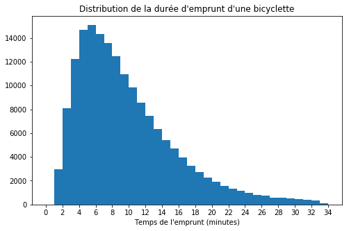

## Distribution de l'heure d'emprunt d'une bicyclette

Les emprunts sont effectués à toutes les heures du jour comme de la nuit; mais nous avons en général deux principales périodes d'affluence : 8h-9h et 17h-18h. Entre les deux l'affluence est stable, mais après la deuxième, elle décroît lentement en soirée.

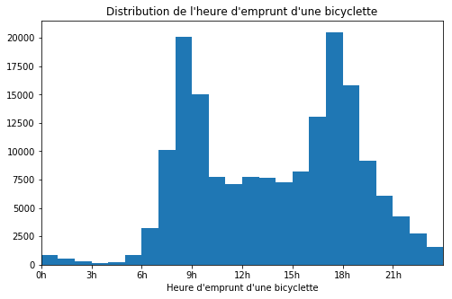

## Durée de l'emprunt vs certaines variables

Nous présentons ici la relation entre la durée de l'emprunt et les trois variables suivantes : âge de l'emprunteur, genre de l'emprunteur, type d'utilisateur de l'emprunteur.

### Durée de l'emprunt vs Âge de l'emprunteur

Les plus longs trajets (plus de 20 minutes) sont essentiellement effectués par des personnes de 21 à 42 ans. On remarque également que plus l'âge est avancé, moins l'emprunteur a tendance à prolonger son temps à vélo. Par exemple les trajets effectués par les personnes de plus de 63 ans font rarement plus de 12 minutes.

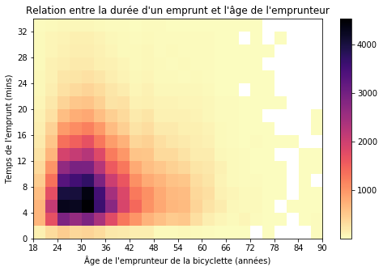

### Durée de l'emprunt vs Genre de l'emprunteur

Les emprunts effectués par les femmes ont tendance à mettre plus de temps que ceux effectués par les hommes, en moyenne une minute de plus (pour cette visualisation, nous ne tenons pas compte du genre "Other").

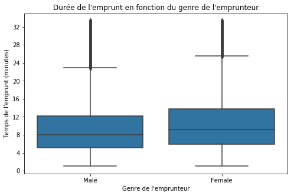

### Durée de l'emprunt vs Type d'utilisateur

Les emprunts effectués par les personnes de type Customer sont en généralement nettement plus longs que ceux effectués par les personnes Subscriber. Ce diagramme en violon nous permet notamment de voir qu'en terme de fréquence relative, pour les emprunts de plus de 1000 secondes par exemple, on a plus de trajets Customer que de trajets Subscriber.

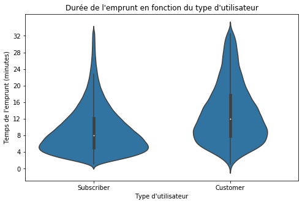

## Heure d'emprunt vs certaines variables

Nous présentons ici la relation entre l'heure de l'emprunt et les deux variables suivantes : âge de l'emprunteur, le jour de la semaine.

### Heure de l'emprunt vs Âge de l'emprunteur

Jusqu'à environ 63 ans, les emprunts sont effectués quasiment à toutes les heures. Mais on remarque qu'après cet âge, les trajets se font essentiellement à partir de 5h ou 6h du matin; ce qui est normal car les personnes de cet âge ont généralement besoin de plus de repos la nuit. De plus à partir de 77 ans, aucun emprunt de bicyclette ne se fait après 18h.

On peut donc dire que les personnes âgées ont tendance à ne pas emprunter de bicyclettes trop tôt le matin ni trop tard le soir.

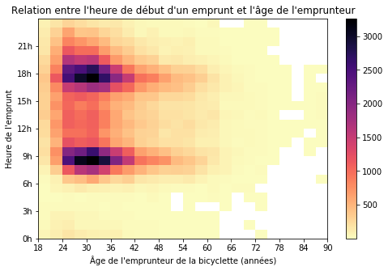

### Heure de l'emprunt vs Jour de la semaine

En semaine l'heure d'emprunt croit progressivement jusqu'à jeudi, avant de décroitre vendredi, où à midi la moitié des emprunts de la journée ont déjà été effectués, au lieu de 14h ou 15h pour les précédents jours. La situation est différente le week-end. Les gens n'ont pas tendance à emprunter tôt le matin surtout le dimanche; en témoignent les quelques points aberrants qu'on voit ces jours. Autre remarque : ces deux jours on n'observe pas les périodes de pics à 8h et 17h comme en semaine. L'affluence croît progressivement de 6h à 14h environ avant de décroître de la même façon jusque dans la nuit.

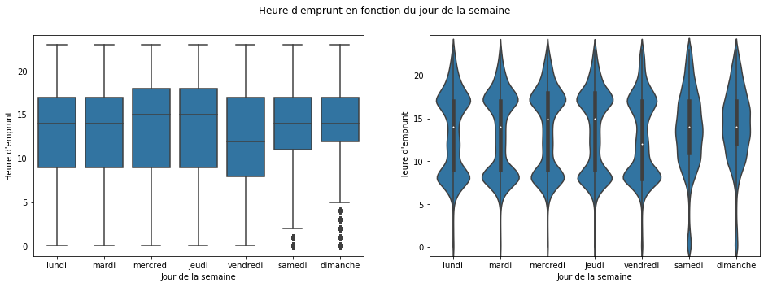

## Durée de l'emprunt chaque jour de la semaine en fonction du genre de l'emprunteur

Nous avons pu observer qu'en général les emprunts de bicyclette féminins ont tendance à mettre plus longs que les masculins. La même observation est faite pour chaque jour de la semaine; on note également pour les emprunts masculins comme pour les emprunts féminins une augmentation de la durée les jours de week-end.

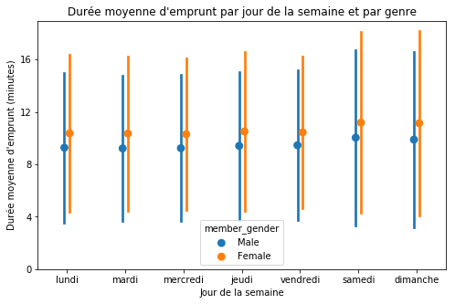

## Durée de l'emprunt chaque jour de la semaine en fonction du type d'utilisateur

Comme observé précédemment, chaque jour de la semaine les emprunts effectués par les utilisateurs de type Customer sont en général beaucoup plus longs que ceux effectués par les utilisateurs Subscriber.

Mais on note un détail très intéressant : alors que le week-end la moyenne de durée des Customer augmente, celle des Subscriber reste constante ! Donc l'augmentation générale des temps de emprunts le week-end constatée lors de l'exploration bivariée serait due uniquement à l'augmentation des temps des utilisateurs Customer.

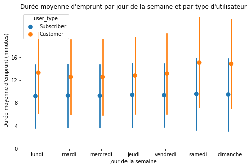